# Making plots with `ggplot2`: Barplots and Scatterplots

We can change both the bar fill colors and outline colors displayed on the figure, by adding the `color` and `fill` arguments to our `geom` function.

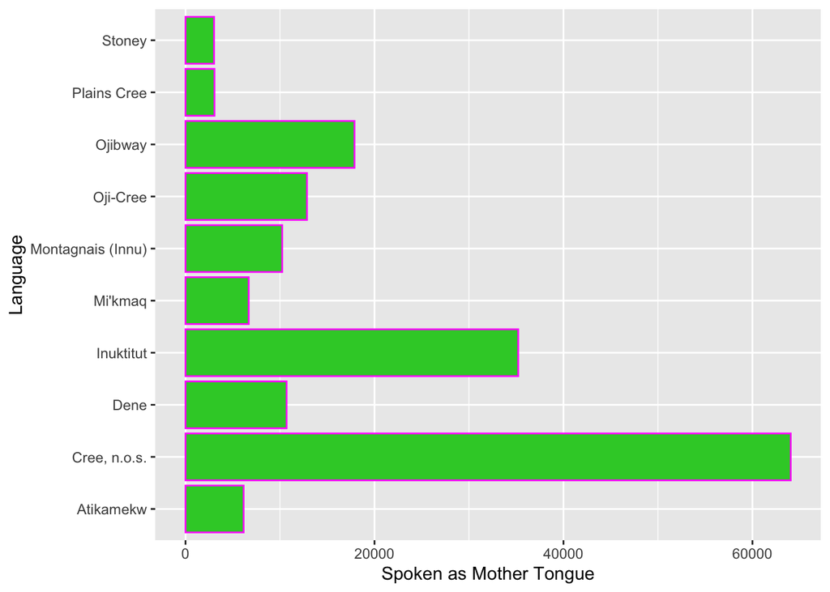

```r
# change bar colors using color= and fill=

ten_lang |>
  ggplot(aes(y=language, x=mother_tongue)) +
  geom_col(color="magenta", fill="limegreen") +
  xlab("Spoken as Mother Tongue") +
  ylab("Language")
```

We can further control the appearance of our figures with `themes`.

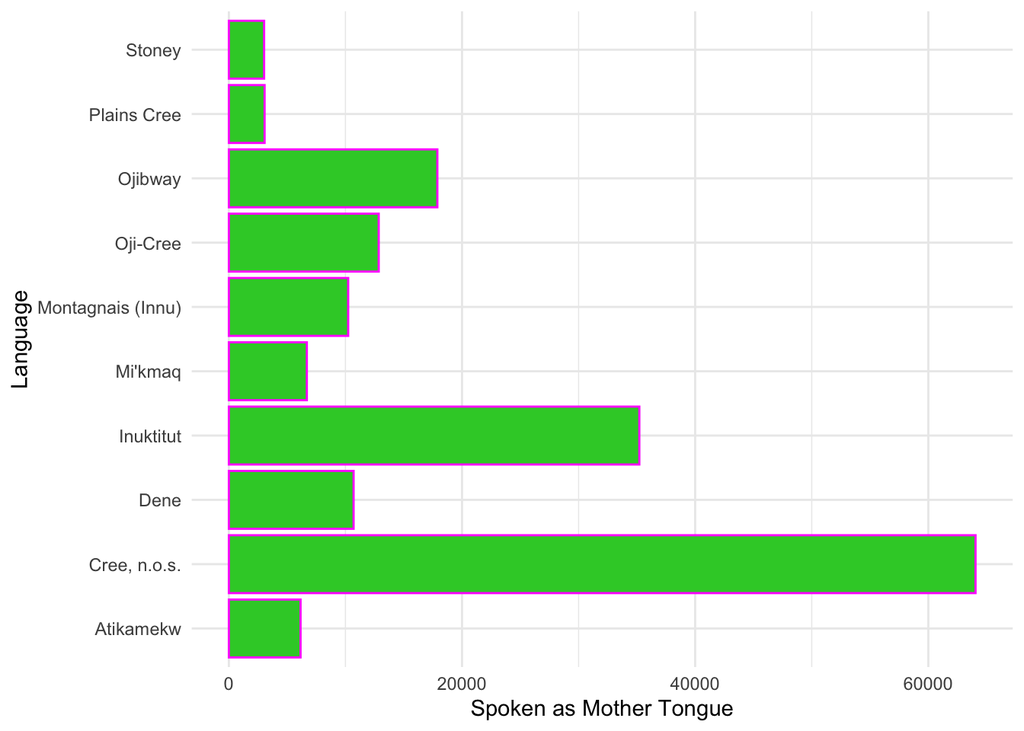

```r
# play around with themes
ten_lang |>
  ggplot(aes(y=language, x=mother_tongue)) +
  geom_col(color="magenta", fill="limegreen") +
  xlab("Spoken as Mother Tongue") +
  ylab("Language") +
  theme_minimal()
```

You can find visualizations of all of the themes included in the `ggplot2` package [here](https://ggplot2.tidyverse.org/reference/ggtheme.html). There are additional packages such as the `ggthemes` package that have even more themes. And if you are feeling really fancy, you can make your own custom theme (please don’t do this right now).

And then finally we can add a title to the figure using the `ggtitle()` function.

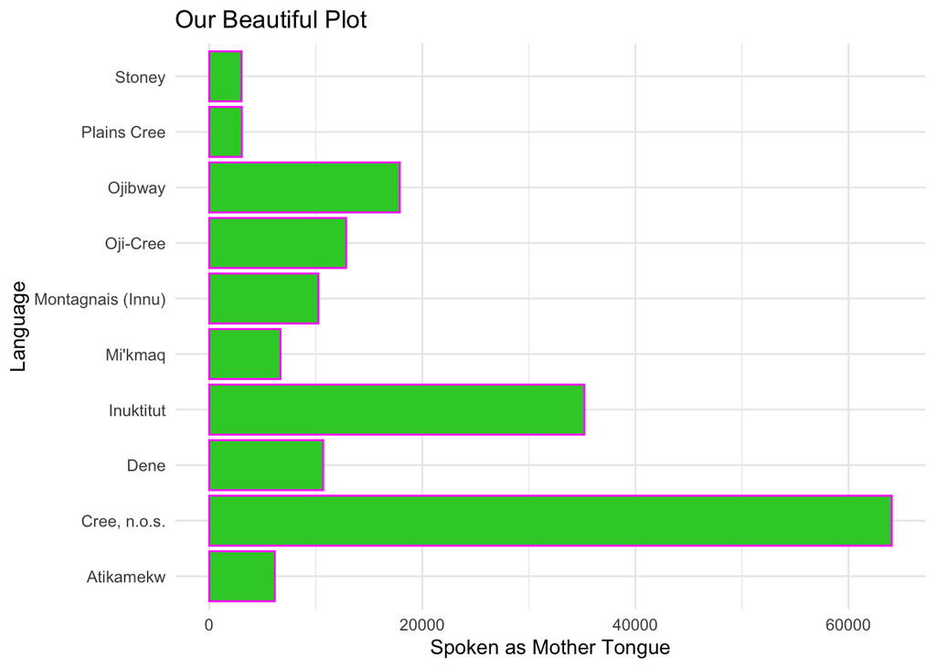

```r
# add a title

ten_lang |>
  ggplot(aes(y=language, x=mother_tongue)) +
  geom_col(color="magenta", fill="limegreen") +
  xlab("Spoken as Mother Tongue") +
  ylab("Language") +
  ggtitle("Our Beautiful Plot") +
  theme_minimal()
```